# Small Business Mythology vs US Business Data

Pawel Rzeczkowski

2022-12-27

# Abstruct

It is almost impossible to live in USA and not be subjected to some version of the mythology that small business is the heartbeat of the US economy.

Given that business concentration in US is not evenly distributed across all states, some of the messaging is [poiticians pandering to small businesses for support, endorsements and campaign contributions.](https://www.sbc.senate.gov/public/)

Another source of bias comes from enterprises catering their services to small businesses thus leaning in with patronizing language to support the popular small business mythology. [A case and point would be a small business lender.](https://www.fundera.com/blog/small-business-statistics)

My lived experiance does not colaborate the Small Business mythology. Bellow is a table dividing what I get from small vs big business:

#### Big Business Provides

- Clothing I ware
- Hygine products
- Electronics that enable my communication
- Financial products
- Transportation that get’s me around
- Condiments on my food
- Any drink I touch
- Supermarkets where I buy all of this

#### Small Business Provides

- My gardner
- My kids nany
- My hairdresser
- My masseuse

*FYI: hypothetical, I can’t afford any of those services*

Faced with this dissonance of public messaging versus my lived experiance, I crave real hardcore data to shed light on composition of business in USA.

I found that no matter how much stories about Small Business warm your heart, the data provided by goverment statistics on all US businesses does not support the small business mythology.

What follows is the detail look at the public data on US business. If you are not interested in the data preperation and cleaning, feel free to jump down to the Analysis section.

# Support

Luckily we do not have to rely on mythology to interpret our world. The big business that is our goverment collects and publishes volumens of data.

[Statistics of U.S. Businesses (SUSB)](https://www.census.gov/data/datasets/2019/econ/susb/2019-susb.html) is an annual series that provides national and subnational data on the distribution of economic data by establishment industry & enterprise size. It is based on this data that people distinguish between small business, emplying less than 500 people or big business, employing 500 or more people.

To do the analysis I will use the latest avilable year which is 2019.

If you want to follow along the data analysis, download the [U.S. & states, 6 digit NAICS (50.3 MB)](https://www2.census.gov/programs-surveys/susb/datasets/2019/us_state_6digitnaics_2019.txt) comma delimited text file. This is 568,330 rows across 14 collumns of business data.

# Process

Before we start wrangling the data, proper claning and organizing is in order.

First let’s load ’ the packages we need to do the analysis, ‘tidyverse’, ‘scales’, ‘ggthemes’.

```r
install.packages("tidyverse", repos = "http://cran.us.r-project.org")
library(tidyverse)
install.packages("ggthemes", repos = "http://cran.us.r-project.org")
library(ggthemes)

install.packages("scales", repos = "http://cran.us.r-project.org")
library(scales)
install.packages("data.tables", repos = "http://cran.us.r-project.org")
library(data.table)
```

Import the 50.3 MB text file you downloaded from the goverment link I provided and load the us_state_6digitnaics_2019 table. For ease of use I converted my file to csv format.

```r
SBA2019 <- read.csv("/Users/pawelrzeczkowski/Google Drive/Goggle Certificate/Portfolio Projects/SBA Job Creators/us_state_6digitnaics_2019.csv",
                      header=TRUE, fileEncoding = "UTF-8")
```

Now is time to clean up some data.

The government issued table contains multiple levels of summaries along three distinct hierarchies. In order to analyse the data we need to strip out all the summaries.

Enterprise Employment Size Description is one of the fields with summaries. The business census data is organized by how many people the enterprise emplys: * <5 * 5-9 * 10-19 * 20-99 * 100-499 * 500+

On top of those basic groupings three summaries are included in the data: * Total * <20 * <500

Let’s eliminate the summaries.

```r
SBA2019 <- SBA2019[which(SBA2019$ENTRSIZEDSCR != "05: <20"), ]
SBA2019 <- SBA2019[which(SBA2019$ENTRSIZEDSCR != "08: <500"),]
SBA2019 <- SBA2019[which(SBA2019$ENTRSIZEDSCR != "01: Total"),]
```

Besides the States detail being provided for the businesses location, the data includes a summary for the United States. Let’s eliminate that.

```r
SBA2019 <- SBA2019[SBA2019$STATEDSCR != "United States",]
```

Finally, we have the [NAICS or Industry classification hierarchy.](https://www.census.gov/programs-surveys/economic-census/year/2022/guidance/understanding-naics.html) At the highest level of the hierarchy the industries are represented with a two-digit classification code. At the lowest level of the hierarchy the industry detail is represented with a six digit code.

I have tested the acuracy of the two-digit level detail vs the six-digit level detail and the two-digit detail is more accurate vs the government provided summaries. Perhaps this discrepancy is where the good enough for government work moniker comes from. The detail does not roll up exactly to the provided summaries. This will not impact this analysis as the 4% difference on number of firms is not material to the result. At the two-digit hierarchy level, the payroll and employee data are consistent with the summary level provided, thus I will use the two-digit sumary level for industry breakout.

Let’s eliminate the industry summaries first.

```r
            SBA2019 <- SBA2019[SBA2019$NAICSDSCR != "Total",]
```

Getting to a clean two-digit level summary is slightly complicated by presentation groupings of industries such as 31-33 Manufacturing, 44-45 Retail Trade and 48-49 Transportation and Warehousing.

I am going to make a copy of the field with the hierarchy listing. Next I’ll isolate the 3rd character. If the character is a dash “-” that means its two-digit grouping and if the character is a space, it means it is a two-digit grouping. I will eliminate all other records.

```r
SBA2019$NAICSmix <- SBA2019$NAICS
SBA2019$NAICSmix <- substr(SBA2019$NAICSmix, start = 3, stop = 3)
SBA2019$NAICSmix[SBA2019$NAICSmix == ""] <- "ThisOne"
SBA2019$NAICSmix[SBA2019$NAICSmix == "-"] <- "ThisOne"
SBA2019 <- SBA2019[SBA2019$NAICSmix == "ThisOne",]
SBA2019$NAICSmix <- NULL
```

Let’s do a quick check to see how the data detail I extracted from the table compares to the government provided summary. I will divide the summary of the detail by the provided summary.

```r
              SBA2019 %>% summarize(Employees = (sum(EMPL)/132000000)*100,
                                Payroll = (sum(PAYR)/7428553593)*100,
                                Firms = (sum(FIRM)/6102412)*100) %>%
              mutate_if(is.numeric, round, digits=1)
```

```
##   Employees Payroll Firms
## 1     100.7     100 104.6
```

Almost 100 percent across the board, we will call this close enough for government work. If you know someone at the census bureau, let them know their statistics are slighly off, or let me know what I am doing wrong.

Now we need little cosmetic work on the table.

In order to create a stacked bar graph breaking out the composition of the various firm sizes that make up the small business in USA, I need a field that only clasifies records as: * Small Business or Enterprise with less than 500 empyees on average * Big Business or Enterprise with more than 500 emplyees on average

Let’s create such column:

```r
SBA2019$ENTR_SUM <- SBA2019$ENTRSIZEDSCR
SBA2019$ENTR_SUM[SBA2019$ENTR_SUM == "02: <5"] <- "<500"
SBA2019$ENTR_SUM[SBA2019$ENTR_SUM == "03: 5-9"] <- "<500"
SBA2019$ENTR_SUM[SBA2019$ENTR_SUM == "04: 10-19"] <- "<500"
SBA2019$ENTR_SUM[SBA2019$ENTR_SUM == "06: 20-99"] <- "<500"
SBA2019$ENTR_SUM[SBA2019$ENTR_SUM == "07: 100-499"] <- "<500"
SBA2019$ENTR_SUM[SBA2019$ENTR_SUM == "09: 500+"] <- "500+"
```

Since we will be graphing using the enterprize size buckets and I deleted several that were redundant groupings, let’s clean up the order of the bucket descriptions.

```r
SBA2019$ENTRSIZEDSCR[SBA2019$ENTRSIZEDSCR == "02: <5"] <- "01: <5"
SBA2019$ENTRSIZEDSCR[SBA2019$ENTRSIZEDSCR == "03: 5-9"] <- "02: 5-9"
SBA2019$ENTRSIZEDSCR[SBA2019$ENTRSIZEDSCR == "04: 10-19"] <- "03: 10-19"
SBA2019$ENTRSIZEDSCR[SBA2019$ENTRSIZEDSCR == "06: 20-99"] <- "04: 20-99"
SBA2019$ENTRSIZEDSCR[SBA2019$ENTRSIZEDSCR == "07: 100-499"] <- "05: 100-499"
SBA2019$ENTRSIZEDSCR[SBA2019$ENTRSIZEDSCR == "09: 500+"] <- "06: 500+"
```

I will want to look at the relationship between firm size and employee pay. To do that I need to add two calculated fields. One is average employees per firm and the other is average salary per emplyee. Let’s add those.

```r
SBA2019$EMPL_FIRM <-SBA2019$EMPL /SBA2019$FIRM
SBA2019$PAY_EMPL <-SBA2019$PAYR /SBA2019$EMPL
```

Finally for clarity, lets make some of the collumn names more meaningful.

```r
colnames(SBA2019)[colnames(SBA2019) == "STATE"] <- "STATE_No"
colnames(SBA2019)[colnames(SBA2019) == "STATEDSCR"] <- "STATE"
colnames(SBA2019)[colnames(SBA2019) == "PAYR"] <- "ANNUAL_PAY"
colnames(SBA2019)[colnames(SBA2019) == "FIRM"] <- "FIRMS"
colnames(SBA2019)[colnames(SBA2019) == "NAICSDSCR"] <- "INDUSTRY"
colnames(SBA2019)[colnames(SBA2019) == "ENTRSIZEDSCR"] <- "Business_Size"
```

This will do it for the cleaning and manipulation of the data. Now let’s look at the data.

# Analysis

US Census Bureau classifies sall businesses as those under 500 employees. Big business is any business that has more than 500 employees. For simplicity, I’ll only look at the employee based classification. Another classification option is by revenue, howevar that varies by industry.

### Majority of The Busineeses Are Small Businesses

We have strong expectation that overwelming majority of US businesses are small businesses. Lets take a look at the number of firms by business size.

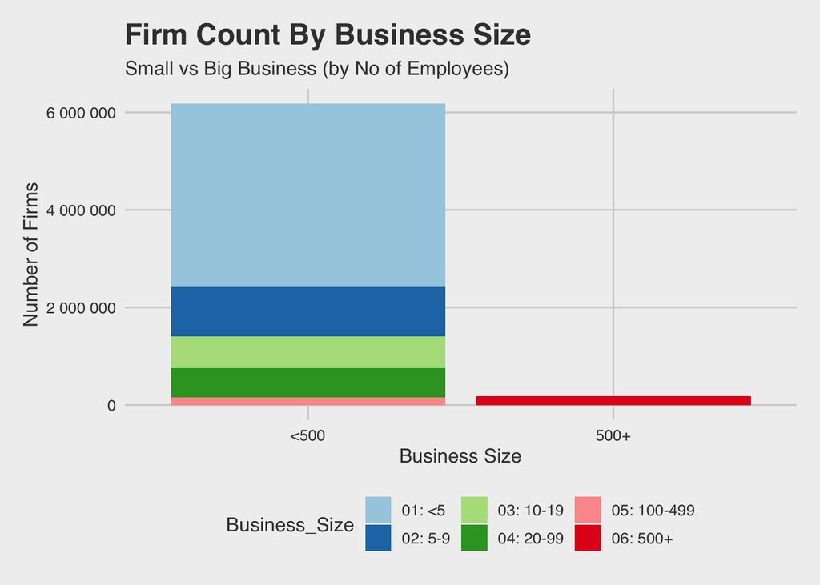

```r
              ggplot(data=SBA2019[SBA2019$PAY_EMPL < 250,],
                   aes(ENTR_SUM, FIRMS, fill=Business_Size)) +
              geom_bar(stat = "summary", fun = "sum") +
              labs(title = "Firm Count By Business Size",
                   subtitle = "Small vs Big Business (by No of Employees)",
                   x = "Business Size",
                   y = "Number of Firms",
                   color = "Region") +
              theme_fivethirtyeight() +
              theme(axis.title = element_text()) +
              scale_fill_brewer(palette = "Paired") +
              scale_y_continuous(labels=scales::unit_format(suffix = ""))
```

This is a yawn, an expected result.

### More of US Work for Big Business

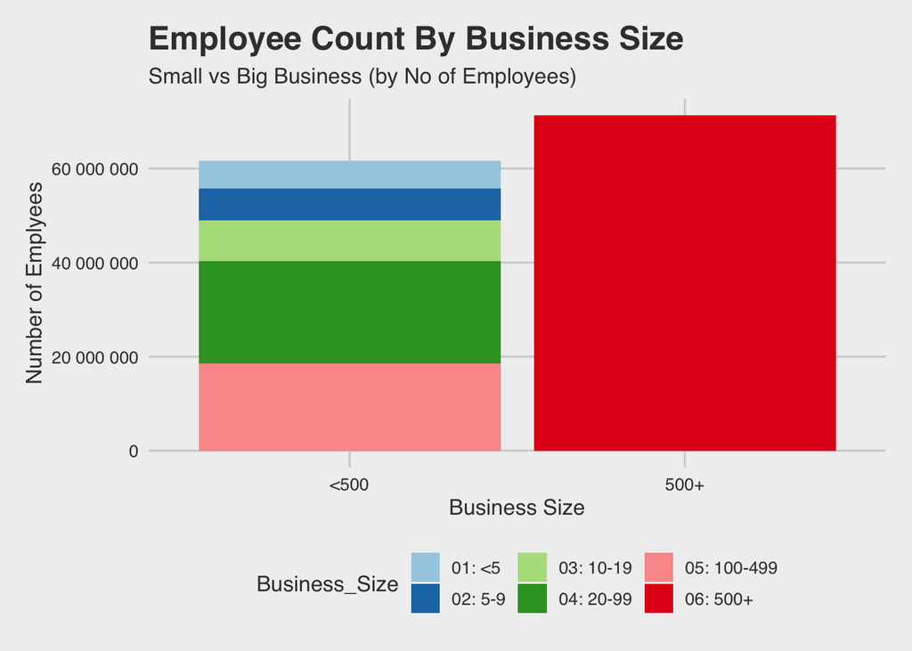

```r
              ggplot(data=SBA2019[SBA2019$PAY_EMPL < 250,],
                   aes(ENTR_SUM, EMPL, fill=Business_Size)) +
              geom_bar(stat = "summary", fun = "sum") +
              labs(title = "Employee Count By Business Size",
                   subtitle = "Small vs Big Business (by No of Employees)",
                   x = "Business Size",
                   y = "Number of Emplyees",
                   color = "Region") +
              theme_fivethirtyeight() +
              theme(axis.title = element_text()) +
              scale_fill_brewer(palette = "Paired") +
              scale_y_continuous(labels=scales::unit_format(suffix = ""))
```

### In Agregate Big Business Pays us More

Let’s forget for a moment that salary is not a comprehensive metric of compensation as executives get paid with equity, and all of us worker bees hope to benefit from some medical and 401K benefits. For simplicity we will just look at the data we have which is salary only.

Let’s be generous to the small business myth and lets say that we are roughly split 50/50. About half of us works for small business and the other half for big business. Howaver when we add up all the salaries, the answare is clear. Big business pays more.

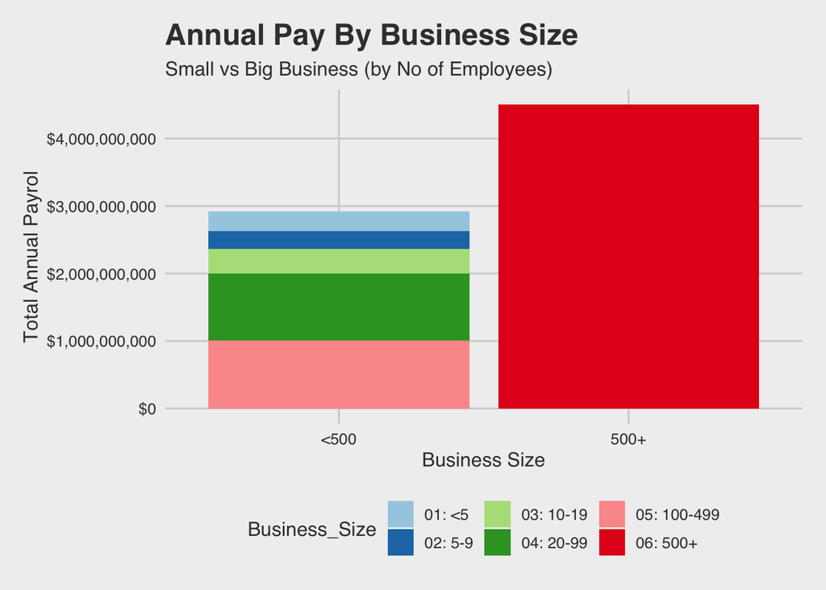

```r
              ggplot(data=SBA2019[SBA2019$PAY_EMPL < 250,],
                   aes(ENTR_SUM, ANNUAL_PAY, fill=Business_Size)) +
              geom_bar(stat = "summary", fun = "sum") +
              labs(title = "Annual Pay By Business Size",
                   subtitle = "Small vs Big Business (by No of Employees)",
                   x = "Business Size",
                   y = "Total Annual Payrol",
                   color = "Region") +
              theme_fivethirtyeight() +
              theme(axis.title = element_text()) +
              scale_fill_brewer(palette = "Paired") +
              scale_y_continuous(labels=scales::dollar_format())
```

Howaver, you scratch your head and say:“Wait a minute! What about all the highly compensated big business executive? Are they not scewing the numbers?” Well, the bigest part of their comp is likely not included in the censous buro salary statistics. Though lets oll at the data by emplloyee.

### Bigger Business Bigger Pay Per Employee

Lets look for relationship between the average pay and business size.

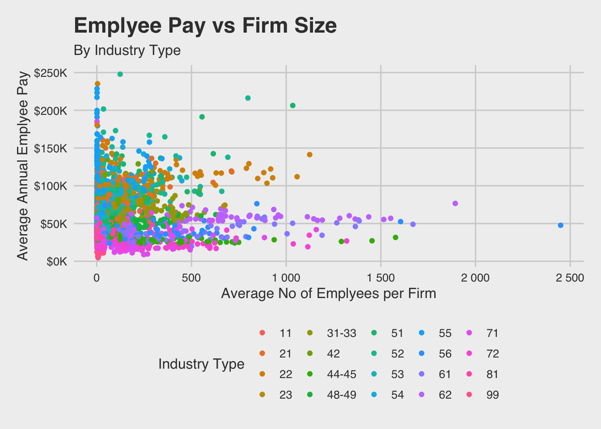

```r
              ggplot(data=SBA2019[SBA2019$PAY_EMPL < 250,]) +
              geom_point(mapping=aes(x=EMPL_FIRM, y=PAY_EMPL, color = NAICS)) +
              labs(title = "Emplyee Pay vs Firm Size",
                   subtitle = "By Industry Type",
                   x = "Average No of Emplyees per Firm",
                   y = "Average Annual Emplyee Pay",
                   color = "Industry Type") +
              theme_fivethirtyeight() +
              theme(axis.title = element_text()) +
              scale_fill_brewer(palette = "Paired") +
              scale_y_continuous(labels=scales::dollar_format(suffix = "K")) +
              scale_x_continuous(labels=scales::unit_format(suffix = ""))
```

The colors represent industry classifications. Diving into the specific industries would be fascinating, but that’s a topic for another analysis.

I am interested if in general the average salaries have a positive relationship with the business size. Let’s add a trend line for all the various industries.

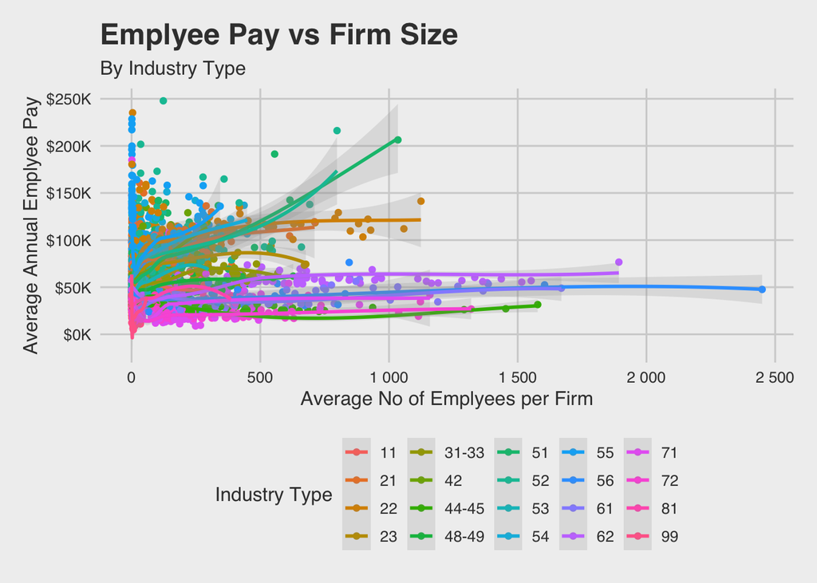

```r
              ggplot(data=SBA2019[SBA2019$PAY_EMPL < 250,]) +
              geom_point(mapping=aes(x=EMPL_FIRM, y=PAY_EMPL, color = NAICS)) +
              geom_smooth(mapping=aes(x=EMPL_FIRM, y=PAY_EMPL, color=NAICS,
                                      alpha= 0.2), alpha= 0.2) +
              labs(title = "Emplyee Pay vs Firm Size",
                   subtitle = "By Industry Type",
                   x = "Average No of Emplyees per Firm",
                   y = "Average Annual Emplyee Pay",
                   color = "Industry Type") +
              theme_fivethirtyeight() +
              theme(axis.title = element_text()) +
              scale_fill_brewer(palette = "Paired") +
              scale_y_continuous(labels=scales::dollar_format(suffix = "K")) +
              scale_x_continuous(labels=scales::unit_format(suffix = ""))
```

Obviously results vary by industry, though overall the average salary tends to increase or stay flat as size of the business grows. But lets take a look at average salaries for bug and small business.

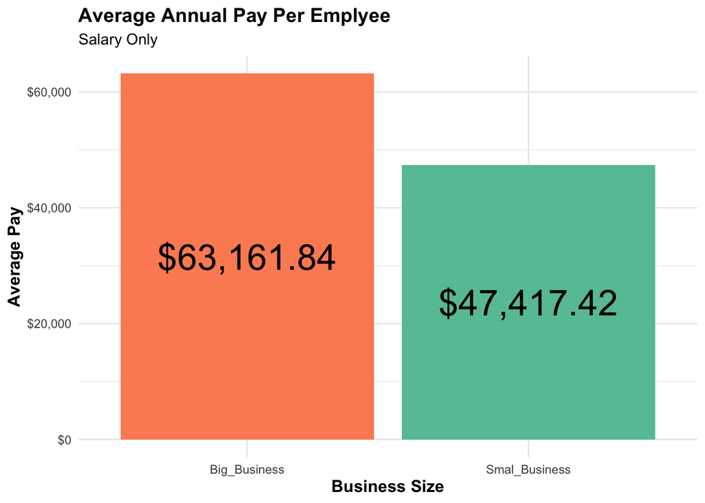

```r
            SB <- SBA2019[SBA2019$ENTR_SUM == "<500",]
            BB <- SBA2019[SBA2019$ENTR_SUM == "500+",]
            Total <- sum(SBA2019$ANNUAL_PAY)/sum(SBA2019$EMPL)
            Big_Business <- sum(BB$ANNUAL_PAY)/sum(BB$EMPL)
            Smal_Business <- sum(SB$ANNUAL_PAY)/sum(SB$EMPL)
            PAY_MORE <- data.table(Smal_Business, Big_Business)

            ggplot(data = NULL, aes(x = names(PAY_MORE), y = as.numeric(PAY_MORE)*1000)) +
              geom_bar(stat = "identity", aes(fill=as.character(PAY_MORE))) +
              labs(title = "Average Annual Pay Per Emplyee",
                   subtitle = "Salary Only",
                   x = "Business Size",
                   y = "Average Pay",
                   color = "Region") +
              geom_text(aes(label = dollar(as.numeric(PAY_MORE)*1000)),
                        position = position_stack(vjust = 0.5), size = 9)+
              theme_minimal() +
              theme(axis.title = element_text(size = 12, face = "bold"),legend.position = "none",
                    plot.title = element_text(size = 14, face = "bold")) +
              scale_fill_brewer(palette = "Set2") +
              scale_y_continuous(labels=scales::dollar_format())
```

Thus based on the Census Bureau Statistics of U.S. Businesses, we can confirm with some authority that the notion that small business is a heartbeat or main driver of US economy is a myth. We need to look closer at the motivation of the politicians or businesses perpetuating this myth to grasp their incentives.

#### The data shows clearly that:

- More of us work for big businesses.
- Those of us who work for big businesses:
  - tend to make more money in aggregate,
  - and on average as individuals.

# Next

### Additional Analysis That Would Be Helpful

- Breakdown the composition of the 5 employees or less businesses.
- Statistic on business revolving doors and the talent that goes through them.
- Impact of legal incentives around business structure including the tax code.
- List of technology trends as drivers of business structure change.

### Context for The Additional Analysis Ideas

Apple, Amazon, Google, Hewlett-Packard, or Microsoft, are but a handful of companies that started out in a garage. For last few years the FANGs market capitalization dominated the public exchanges. Such companies animate every Venture Capitalists wet dreams. The graph of number of big vs small businesses underscores how rare such growth is. To translate this to mainstream speak, your garage band has more of a chance being struck by lightning than becoming U2. Don’t trust me, ask ChatGPT.

Juxtaposing the small business mythology vs the big business dominance reality founded in data, my curiosity wonders into the cultural and regulatory environment that reflexively is the fertile soil out of which our business structures emerge. If the small business pandering is happening among the members of the legislative body settling laws in our society the analysis of that might be few notches above my pay grade as an analyst.

It is also important to note that the data annualized is historical. We are looking into the rear-view mirror. However, as our economy transforms into the network economy model, it would be interesting to analyze the platforms dependencies and how that changes the structural reality of business competitiveness and composition in our economy. I am referring not just to the dependencies of influencers and the corporate advertising budgets that power them on platforms but also on the shift the tech drives from transaction to relationship and how that changes the business landscape.

This simple analysis raises million more questions than it answers. Hope you enjoyed it as much as I did.